# Metrics_video2_constants_for_MSE_and_MAE

This document briefly explains why target mean value minimizes MSE error and why target median minimizes MAE.

Suppose we have a dataset $$ \{(x_i,y_i)\}_{i=1}^N $$

Basically, we are given pairs: features $x_i$ and corresponding target value $y_i \in \mathbb{R}$.

We will denote vector of targets as $y \in \mathbb{R}^N$, such that $y_i$ is target for object $x_i$. Similarly, $\hat y \in \mathbb{R}$ denotes predictions for the objects: $\hat y_i$ for object $x_i$.

# MSE

Let's start with MSE loss. It is defined as follows:

$$ MSE(y, \hat y) = \frac{1}{N} \sum_{i=1}^N (\hat y_i - y_i)^2 $$

Now, the question is: if predictions for all the objects were the same and equal to $\alpha$: $\hat y_i = \alpha$, what value of $\alpha$ would minimize MSE error?

$$ \min_{\alpha} f(\alpha) = \frac{1}{N} \sum_{i=1}^N (\alpha - y_i)^2 $$

The function $f(\alpha)$, that we want to minimize is smooth with respect to $\alpha$. A required condition for $\alpha^*$ to be a local optima is $$ \frac{d f}{d \alpha}\bigg|_{\alpha=\alpha^*} = 0\, . $$

Let's find the points, that satisfy the condition:

$$ \frac{d f}{d \alpha}\bigg|_{\alpha=\alpha^*} = \frac{2}{N} \sum_{i=1}^N (\alpha^* - y_i) = 0 $$$$ \frac{2}{N} \sum_{i=1}^N \alpha^* - \frac{2}{N} \sum_{i=1}^N y_i = 0 $$$$ \alpha^* - \frac{1}{N} \sum_{i=1}^N y_i = 0 $$

And finally: $$ \alpha^* = \frac{1}{N} \sum_{i=1}^N y_i $$

Since second derivative $\frac{d^2 f}{d \alpha^2}$ is positive at point $\alpha^*$, then what we found is local minima.

So, that is how it is possible to find, that optial constan for MSE metric is target mean value.

# MAE

Similarly to the way we found optimal constant for MSE loss, we can find it for MAE.

$$ MAE(y, \hat y) = \frac{1}{N} \sum_{i=1}^N |\hat y_i - y_i| $$

$$ \min_{\alpha} f(\alpha) = \frac{1}{N} \sum_{i=1}^N |\alpha - y_i| $$

Recall that $ \frac{\partial |x|}{dx} = sign(x)$, where $sign$ stands for [signum function](https://en.wikipedia.org/wiki/Sign_function) . Thus

$$ \frac{d f}{d \alpha}\bigg|_{\alpha=\alpha^*} = \frac{1}{N} \sum_{i=1}^N sign(\alpha^* - y_i) = 0 $$

So we need to find such $\alpha^*$ that

$$ g(\alpha^*) = \sum_{i=1}^N sign(\alpha^* - y_i) = 0 $$

Note that $g(\alpha^*)$ is piecewise-constant non-decreasing function. $g(\alpha^*)=-1$ for all calues of $\alpha$ less then mimimum $y_i$ and $g(\alpha^*)=1$ for $\alpha > \max_i y_i$. The function "jumps" by $\frac{2}{N}$ at every point $y_i$. Here is an example, how this function looks like for $y = [-0.5, 0, 1, 3, 3.4]$:

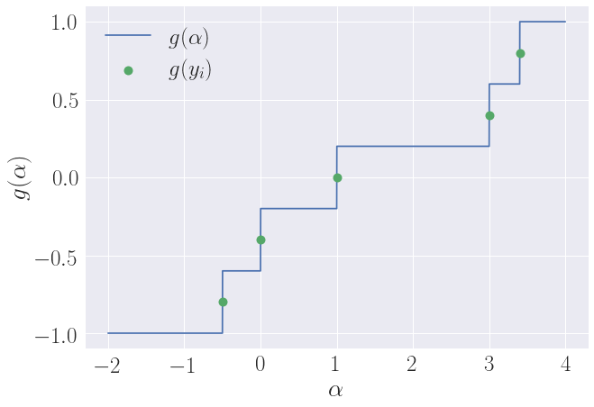

Basically there are $N$ jumps of the same size, starting from $-1$ and ending at $1$. It is clear, that you need to do about $\frac{N}{2}$ jumps to hit zero. And that happens exactly at median value of the target vector $g(median(y))=0$. We should be careful and separate two cases: when there are even number of points and odd, but the intuition remains the same.